# BPB3: BayesPI-BAR version 3 package User Guide

# Demo3:

# Applying bpb3 on Genome-wide Sequencing Data of Follicular Lymphoma Patients

demo3_fl_cohort_small

## Aim and pipeline flow

**Aim** Here, bpb3 is applied on a set of whole-genome sequencing (WGS) and gene expression data from Follicular Lymphoma (FL) patients. By integrating both DNA mutation information and the gene expression data from the same patient, it helps user predict the dysregulation of transcription factors (TFs) when the binding to DNA sequence is affected by mutations (or functional regulatory mutations) in disease. In the new bpb3 package, a pre-compiled input parameter configure file is provided, which can be simply modified by users and be directly loaded by bpb3 package to apply original BayesPI-BAR2 pipeline on different input data automatically. This new function significantly simplifies the application of bpb3 in different tasks, which is demonstrated in Demo3 by analyzing FL cancer cohort data.

**Principle** Based on the patients’ mutation information and the corresponding gene expression profiles, the BPP3 (which includes functions from BayesPI-BAR2) first finds mutation blocks (e.g., with high mutation frequency across patients) at promoter regions of differentially expressed genes - DEGs (e.g., P-value <0.05 of a two-sample Kolmogorov–Smirnov test/T-test between tumor and normal samples). The mutation blocks at gene promoter regions are identified by *MuSSD* (Mutation filtering based on the Space and Sample Distribution) algorithm ([Batmanov et al., 2017](https://ntnuopen.ntnu.no/ntnu-xmlui/bitstream/handle/11250/2485105/1485238.pdf?sequence=2&isAllowed=y)), from which the patient specific mutation blocks are exported.

Subsequently, by using a given set of TFs PWMs (e.g., ~1772 human TFs PWMs; reference Figure 1), bpb3 predicts a list of TFs whose binding affinities are significantly changed due to the patient-specific mutation blocks.

The significance test for TF-DNA binding affinity changes is based on following three steps:

1. Foreground calculation: all predicted patient-specific mutation blocks are considered as foreground mutation blocks, which are tested against all available human TFs’ PWMs (~1772 PWMs in Demo2) by using the BayesPI-BAR function in bpb3.
2. Background calculation: background mutation blocks are extracted randomly from regions of interest, which with the same sequence length as patient-specific mutation block. Mutations in each background mutation block are generated based on reference genome by altering the nucleotides in random position with either tumor-derived mutations or a given k-mer mutation probability distribution (the mutation signature).
3. Finally, a comparison between the foreground and the background calculation is carried out for each patient-specific mutation block, where TFs with the distribution of δdbA values are significantly different (e.g., P-value <0.05 in a Wilcoxon rank-sum test) between the foreground and the background calculations are considered as putative target TFs. More detailed description of these tree steps please refer to ([Batmanov et al., 2019](https://www.frontiersin.org/articles/10.3389/fgene.2019.00282/full)).

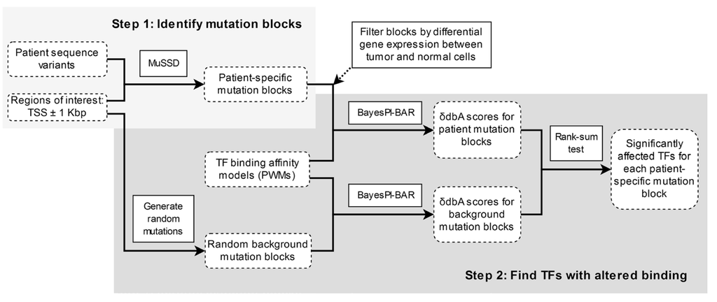

Figure 1. Flowchart of the BayesPI-BAR pipline

## Run job 1.

## Predict patient-specific mutation blocks that significantly affect TF binding affinity at promoter regions of differentially expressed genes

**data input**

Reference files

- final_demo_data/pwm
- final_demo_data/genome_data/hg19/human_g1k_v37_decoy.fasta

Mutation and expression data in patients, here showing one with ID DO52676 from total 10 patients:

- final_demo_data/demo3_fl_cohort_small/patient_data/DO52676/icgc_mutations_on_18.tsv
- final_demo_data/demo3_fl_cohort_small/patient_data/DO52676/DO52676_expression.tsv

*Table 1*: Mutation data, e.g. icgc_mutations_on_18.tsv: Columns V1 - 5 represent chr, position, mutation ID, reference base and mutated base respectively. Total 45 rows (mutations) in the example.

| V1 | V2 | V3 | V4 | V5 |
| --- | --- | --- | --- | --- |
| 18 | 40971327 | MU69438525 | C | T |
| 18 | 66791083 | MU69438602 | G | A |
| 18 | 70510306 | MU69438628 | G | A |
| 18 | 50720716 | MU69438549 | A | G |
| 18 | 30349939 | MU69438484 | T | A |
| 18 | 70179019 | MU69438619 | C | T |
| 18 | 36347000 | MU69438505 | A | T |
| 18 | 50713892 | MU69438538 | C | A |
| 18 | 29987947 | MU31429834 | A | T |
| 18 | 37465342 | MU69438512 | G | A |

*Table 2*: Expression data in patients, e.g. DO52676_expression.tsv, the columns of V1-2 represent gene name and read count respectively. Total 55765 rows.

|  | V1 | V2 |
| --- | --- | --- |
| 1 | WASH7P | 6462 |
| 2 | DDX11L1 | 16 |
| 3 | MIR1302-11 | 0 |
| 4 | FAM138A | 0 |
| 5 | OR4G4P | 0 |
| 6 | OR4G11P | 0 |
| 7 | OR4F5 | 0 |
| 8 | RP11-34P13.7 | 184 |
| 9 | RP11-34P13.8 | 37 |
| 10 | RP11-34P13.14 | 15 |
| 24463 | BCL2 | 19104 |

*Table 3*: Expression data in control, e.g. SRR834983.sorted.only_counts.tsv, the columns of V1-2 represent gene name and counts respectively. Total 55765 rows.

|  | V1 | V2 |
| --- | --- | --- |
| 1 | OR4F5 | 0 |
| 2 | AL627309.1 | 1032 |
| 3 | OR4F29 | 0 |
| 4 | OR4F16 | 0 |
| 5 | AL669831.1 | 5 |
| 6 | AL645608.2 | 1 |
| 7 | SAMD11 | 3 |
| 8 | AL645608.1 | 0 |
| 9 | NOC2L | 4239 |
| 10 | KLHL17 | 765 |
| 16603 | BCL2 | 437 |

**data output**

Main files:

1. final_demo_data/demo3_fl_cohort_small/out/regions.bed
2. final_demo_data/demo3_fl_cohort_small/out/mussd_blocks/mutations_in_regions.tsv
3. /final_demo_data/demo3_fl_cohort_small/out/foreground/block_1_18_60987833_60988302/ddba/ddba_integrated_using_mean_ddba.tsv
4. final_demo_data/demo3_fl_cohort_small/out/tumor_median_patient_rpkm.tsv
5. final_demo_data/demo3_fl_cohort_small/out/normal_median_patient_rpkm.tsv
6. final_demo_data/demo3_fl_cohort_small/out/differentially_expressed_genes.txt

Detail files and folds in out:

- files and folds in: final_demo_data/demo3_fl_cohort_small/out
  - background/
  - demo3_fl_cohort_small_bpb3.log_1654257452.332132
  - demo3_fl_cohort_small_bpb3.log_1655210619.3237617
  - differentially_expressed_genes.txt
  - foreground/
  - make_background.sh
  - mussd_blocks/
  - normal_median_patient_rpkm.tsv
  - regions.bed
  - run_mussd.sh
  - significant_blocks.txt
  - tumor_median_patient_rpkm.tsv
- files and folds in: final_demo_data/demo3_fl_cohort_small/out/foreground/
  - block_0_18_60986372_60987028/
  - block_1_18_60987833_60988302/
- files/folds in final_demo_data/demo3_fl_cohort_small/out/foreground/block_1_18_60987833_60988302
  - dba_alt/ dba_ref/ ddba/ rankings/ result.tsv result_filtered.tsv result_gene_names.tsv result_plot.png

Here, only 2 of PWMs are illustrated: the first motif (AFP) and the interesting motif of FOXL1, where the negative and the positive values represent decreasing and increasing TF binding affinity, respectively, due to the mutation block.

| Sequence_name | AFP_1_from_AFP1_transfac_M00616.mlp | FOXL1_4_from_FOXL1_jolma_full_M423.mlp |
| --- | --- | --- |
| block_1_18_60987833_60988302_patient_10::18:60987807-60988326 | 0 | -0.0005046 |
| block_1_18_60987833_60988302_patient_1::18:60987807-60988326 | 0 | -0.1352854 |
| block_1_18_60987833_60988302_patient_2::18:60987807-60988326 | 0 | -0.1296093 |
| block_1_18_60987833_60988302_patient_3::18:60987807-60988326 | 0 | -0.0424183 |
| block_1_18_60987833_60988302_patient_4::18:60987807-60988326 | 0 | -0.0004782 |
| block_1_18_60987833_60988302_patient_6::18:60987807-60988326 | 0 | 0.0004601 |
| block_1_18_60987833_60988302_patient_7::18:60987807-60988326 | 0 | -0.1932673 |
| block_1_18_60987833_60988302_patient_8::18:60987807-60988326 | 0 | -0.0002303 |
| block_1_18_60987833_60988302_patient_9::18:60987807-60988326 | 0 | -0.0007140 |

*Table 5*: Output of TFs affected by mutation block, in file:

final_demo_data/demo3_fl_cohort_small/out/foreground/block_1_18_60987833_60988302/result.tsv

| direction | pwm_name | bonferroni_p | affected_cases | total_cases |
| --- | --- | --- | --- | --- |
| Positive | TEF_3_from_TEF_jolma_FL_M395.mlp | 0.0165968 | 3 | 9 |
| Positive | AP3_1_from_AP-3_transfac_M00690.mlp | 0.0222525 | 2 | 9 |
| Negative | FOXO4_2_from_FOXO4_transfac_M00476.mlp | 0.0000025 | 9 | 9 |
| Negative | AHR::ARNT_3_from_Arnt::Ahr_jaspar_MA0006.1.mlp | 0.0000083 | 8 | 9 |
| Negative | NKX2-2_2_from_Nkx2-2_bulyk_cell08-2823.1.mlp | 0.0000146 | 9 | 9 |
| Negative | FOXC1_2_from_FOXC1_jaspar_MA0032.1.mlp | 0.0001830 | 7 | 9 |
| Negative | FOXK1_4_from_Foxk1_jolma_DBD_M448.mlp | 0.0009020 | 8 | 9 |
| Negative | FOXO4_4_from_FOXO4_jolma_DBD_M432.mlp | 0.0133266 | 8 | 9 |
| Negative | FOXL1_4_from_FOXL1_jolma_full_M423.mlp | 0.0144236 | 8 | 9 |

*Table 6*: Output of filtering TFs correlation with DEGs, in file: final_demo_data/demo3_fl_cohort_small/out/foreground/block_1_18_60987833_60988302/result_filtered.tsv  
Please notice that one motif (NKX2) has been filtered out in comparison to result.tsv.

| direction | pwm_name | bonferroni_p | affected_cases | total_cases |
| --- | --- | --- | --- | --- |
| Positive | TEF_3_from_TEF_jolma_FL_M395.mlp | 0.0165968 | 3 | 9 |
| Positive | AP3_1_from_AP-3_transfac_M00690.mlp | 0.0222525 | 2 | 9 |
| Negative | FOXO4_2_from_FOXO4_transfac_M00476.mlp | 0.0000025 | 9 | 9 |
| Negative | AHR::ARNT_3_from_Arnt::Ahr_jaspar_MA0006.1.mlp | 0.0000083 | 8 | 9 |
| Negative | FOXC1_2_from_FOXC1_jaspar_MA0032.1.mlp | 0.0001830 | 7 | 9 |
| Negative | FOXK1_4_from_Foxk1_jolma_DBD_M448.mlp | 0.0009020 | 8 | 9 |
| Negative | FOXO4_4_from_FOXO4_jolma_DBD_M432.mlp | 0.0133266 | 8 | 9 |
| Negative | FOXL1_4_from_FOXL1_jolma_full_M423.mlp | 0.0144236 | 8 | 9 |

*Table 7*: Output in file: final_demo_data/demo3_fl_cohort_small/out/differentially_expressed_genes.txt

The table contains 15044 gene IDs (V1), the first column of values (V2) is P-value to differentially expressed gene analysis (e.g., the T-test), and the rest of columns (V3-V16) are gene expression profiles of 14 samples (10 FL patients and 4 normal samples). In below table, the first 5 genes and gene BCL2 are illustrated.

|  | V1 | V2 | V3 | V4 | V5 | V6 | V7 | V8 | V9 | V10 | V11 | V12 | V13 | V14 | V15 | V16 |
| --- | --- | --- | --- | --- | --- | --- | --- | --- | --- | --- | --- | --- | --- | --- | --- | --- |
| 1 | A1BG | 0.0068416 | 0.7943659 | 0.9030098 | 0.7271231 | 0.7682776 | 0.9032575 | 0.9586229 | 0.8600161 | 1.1129623 | 1.0044719 | 1.0356217 | 0.7647033 | 0.7540874 | 0.6272536 | 0.7743943 |
| 2 | A2M | 0.0000001 | 1.8944650 | 2.0495221 | 1.3698922 | 1.7241477 | 2.5127462 | 1.1921792 | 1.9616053 | 2.0831787 | 1.5722363 | 1.7068617 | 0.1306157 | 0.0293570 | 0.1195554 | 0.0268533 |
| 3 | A2ML1 | 0.0132432 | 0.0028448 | 0.0044049 | 0.0068675 | 0.0035200 | 0.0066887 | 0.0123181 | 0.0066518 | 0.0124086 | 0.0052232 | 0.0038342 | 0.0787104 | 0.0372975 | 0.0931292 | 0.0930697 |
| 4 | A3GALT2 | 0.0230457 | 0.0051359 | 0.0092533 | 0.0159486 | 0.0191970 | 0.0305474 | 0.0126502 | 0.0237832 | 0.0157993 | 0.0095953 | 0.0179192 | 0.0666092 | 0.0724562 | 0.1280139 | 0.0600418 |
| 5 | A4GALT | 0.0000000 | 0.5020783 | 0.4371411 | 0.6373521 | 0.5481718 | 0.4676121 | 0.1414701 | 0.4108477 | 0.3084385 | 0.3165469 | 0.4748409 | 1.3681975 | 1.5529123 | 1.4093888 | 1.4151966 |
| 1474 | BCL2 | 0.0000506 | 0.4372861 | 0.8370532 | 0.7579202 | 0.8955533 | 0.2487375 | 1.0757290 | 0.6261782 | 0.9611831 | 1.0682206 | 0.6459162 | 0.2302093 | 0.1458863 | 0.1945131 | 0.1085880 |

*Table 8*: The median expression level in patients, file in:

final_demo_data/demo3_fl_cohort_small/out/tumor_median_patient_rpkm.tsv  
Here shows the first 10 lines and a interesting gene BCL2

|  | V1 | V2 |
| --- | --- | --- |
| 1 | A1BG | 1.4673227 |
| 2 | A1CF | 0.0019921 |
| 3 | A2M | 5.1283650 |
| 4 | A2ML1 | 0.0059555 |
| 5 | A3GALT2 | 0.0160006 |
| 6 | A4GALT | 0.5722264 |
| 7 | A4GNT | 0.0054710 |
| 8 | AAAS | 4.6634853 |
| 9 | AACS | 0.2357528 |
| 10 | AADAC | 0.0019926 |
| 1971 | BCL2 | 1.2216924 |

*Table 9*: The median expression level in health control, final_demo_data/demo3_fl_cohort_small/out/normal_median_patient_rpkm.tsv

|  | V1 | V2 |
| --- | --- | --- |
| 1 | A1BG | 1.1370137 |
| 2 | A1CF | 0.0027790 |
| 3 | A2M | 0.0783939 |
| 4 | A2ML1 | 0.0897146 |
| 5 | A3GALT2 | 0.0720117 |
| 6 | A4GALT | 3.1053743 |
| 7 | A4GNT | 0.0233732 |
| 8 | AAAS | 2.4730681 |
| 9 | AACS | 0.8838859 |
| 10 | AADAC | 0.0039287 |
| 1971 | BCL2 | 0.1858920 |

**Output of predicted TFs with significant binding affinity changes due to mutation block**

File in: final_demo_data/demo3_fl_cohort_small/out/foreground/block_1_18_60987833_60988302/result_plot.png

The result_plot shows TFs with significant binding affinity changes (either positive or negative), due to a mutation block (block_1_18_60987833_60988302) located at promoter of BCL2 gene. The binding affinity of transcript factors FOXL1 and FOXO4 are negatively affected by this mutation block in most of patients. BCL2 is an oncogene that promotes cell proliferation, which has higher expression in patients than that in control samples. Thus, the predicted decreasing of FOX protein (e.g., FOXL1 and FOXO4) binding near the promoter of BCL2 may link to the dysregulation of BCL2 gene in FL patients. In the current demo, bpb3 automatically predicted this mutation block and the corresponding target TFs. In the heatmap, the increasing (creation of binding sites) and decreasing (destruction of existing binding sites) of TF binding affinity change due to mutation block are shown in orange and purple, respectively.

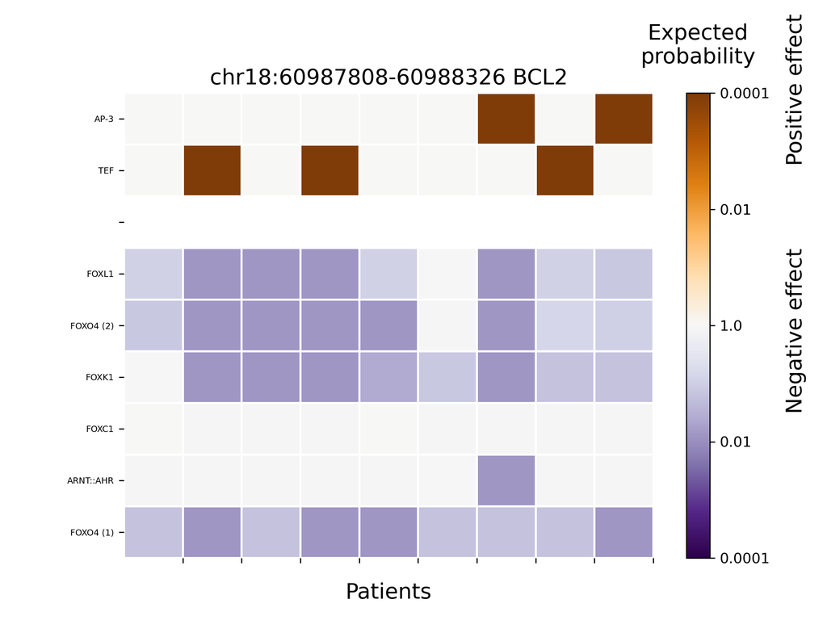

Figure 2. result_plot

**Additional visualization result**

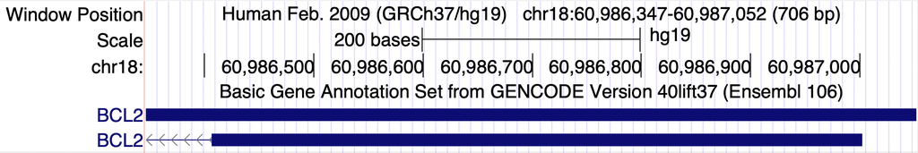

Figure 3. View targeted BCL2 in Genome browser

**Run job**

```bash
sbatch job_bpb3
```

Job script: job_bpb3

```bash
#!/bin/csh

#Job name:
#SBATCH --job-name=demo3-bpb3-fl
#
# Project:
#SBATCH --account=nn4605k
#
# Wall clock limit:
#SBATCH --time=12:00:00
#
# Max memory usage:
#SBATCH --mem-per-cpu=12G
###--partition=bigmem
#
# Number of cores:
#SBATCH --cpus-per-task=12


#run fl cohort demo by using pwm with pipeline configure file
bpb3 run_pipeline --import_bpb3_config bpb3_config.py
```

**Main process**  
The main processes are stored in Slurm file, example:

```
T-test
Export at  final_demo_data/demo3_fl_cohort_small/out/regions.bed
Read , final_demo_data/demo3_fl_cohort_small/out/mussd_blocks/blocks_summary.tsv

No P-value correction is applied in high mutation blocks test
Background block size will be equal to median significant block size: 611
Mutation count distribution:
     number of mutations     probability
     3      0.058823529411764705
     4      0.11764705882352941
     5      0.11764705882352941
     6      0.11764705882352941
     7      0.11764705882352941
     9      0.11764705882352941
     10       0.058823529411764705
     11       0.058823529411764705
     13       0.11764705882352941
     18       0.058823529411764705
     31       0.058823529411764705

174 PWMs are chosen for background model based on foreground rankings (max rank is 15 )
using 1000 background iterations and 6 chemical potential(s): none, -10, -13, -15, -18, -20

Calculating delta-dbA values...

final_demo_data/demo3_fl_cohort_small/out/foreground/block_0_18_60986372_60987028/ddba/ddba_integrated_using_mean_ddba.tsv : 8 mutations,  1772 PWMs
  Negative PWMs at 0.05 bonferroni significance:
     POU3F3_1_from_Pou3f3_bulyk_cell08-3235.2.mlp   bonferroni p: 2.67443726636109e-08  #cases: 8 / 8
     IRX5_1_from_Irx5_bulyk_cell08-2385.1.mlp   bonferroni p: 7.976789006613734e-05     #cases: 7 / 8
     IRX6_1_from_Irx6_bulyk_cell08-2623.2.mlp   bonferroni p: 0.00033008735489452464    #cases: 7 / 8
     IRX3_2_from_Irx3_bulyk_cell08-2226.1.mlp   bonferroni p: 0.0003697353228887798     #cases: 7 / 8
     IRX3_1_from_Irx3_bulyk_cell08-0920.1.mlp   bonferroni p: 0.0004139588783932095     #cases: 7 / 8
     IRX2_1_from_Irx2_bulyk_cell08-0900.3.mlp   bonferroni p: 0.0016353455381908004     #cases: 7 / 8

final_demo_data/demo3_fl_cohort_small/out/foreground/block_1_18_60987833_60988302/ddba/ddba_integrated_using_mean_ddba.tsv : 9 mutations,  1772 PWMs
Positive PWMs at 0.05 bonferroni significance:
     TEF_3_from_TEF_jolma_FL_M395.mlp     bonferroni p: 0.016596803613671534    #cases: 3 / 9
     AP3_1_from_AP-3_transfac_M00690.mlp    bonferroni p: 0.02225249862937881   #cases: 2 / 9
Negative PWMs at 0.05 bonferroni significance:
     FOXO4_2_from_FOXO4_transfac_M00476.mlp     bonferroni p: 2.5338637184472244e-06    #cases: 9 / 9

Add path
 final_demo/demo3_fl_cohort_small

block_0_18_60986372_60987028 :  # length 657 bp
block_1_18_60987833_60988302 :  # 470 bp
Filtering results by gene expression for block block_0_18_60986372_60987028 ...
Filtering results by gene expression for block block_1_18_60987833_60988302 ...
```

**CPU requirement**

- MaxRSS: 17 MB
- Running time: 1 hour 19 min

## Python code

bpb3_config.py

This is a parameter configure file that can be directly loaded by bpb3 package to complete several defined analysis steps. In this file, user can easily edit the configures for modifying parameters or changing the input data before running bpb3.

```python
import os
import glob
from bpb3.script.script_high.other import common
import time

###########Setup main Path ################
#Project Output path
out_data_folder = os.path.abspath("../../final_demo_data/demo3_fl_cohort_small/out")

#input data path
patient_data_folder = os.path.join(out_data_folder,'../', "patient_data")
normal_rnaseq_folder = os.path.join(out_data_folder,'../' ,"normal_gcb_counts")

#project name
project_name='demo3_fl_cohort_small'

#Genome path
#genome data too large which needs to be stored in a separeted place from the demo data in github
genome_folder=os.path.abspath("../../final_demo_data/genome_data/hg19/")
genome_fasta_file= os.path.join(genome_folder, "human_g1k_v37_decoy.fasta")
gene_annotation_file= os.path.join(genome_folder, "gencode.v19.annotation.gtf")

# folder with PWM models for TF binding affinity
pwm_folder = os.path.join("../../final_demo_data/pwm")

# output data folders
foreground_folder = os.path.join(out_data_folder, "foreground")
background_folder = os.path.join(out_data_folder, "background")
background_pwm_folder = os.path.join(out_data_folder, "pwm_for_background")
mussd_result_folder = os.path.join(out_data_folder, "mussd_blocks")

#normal gene expression file name under folder normal_rnaseq_folder
normal_count_files_postprefix="*.only_counts.tsv"
gene_length_file = os.path.join(genome_folder, "gene_lengths.tsv")
#gene expression file name postprefix in folder patient_data_folder
donor_count_files_postprefix="D*/*_expression.tsv"

###########Setup Pipeline parameters #########
#1. Differential gene expression options
differentially_expressed_genes_file = os.path.join(out_data_folder, "differentially_expressed_genes.txt")
group1_str='tumor'
group2_str='normal'
#Export file path
group1_median_rpkm_file = os.path.join(out_data_folder, group1_str + "_median_patient_rpkm.tsv")
group2_median_rpkm_file = os.path.join(out_data_folder, group2_str +"_median_patient_rpkm.tsv")

# maximum Kolmogorov-Smirnov test P value to consider genes as differentially expressed
differential_expression_p = 0.05
# whether to do quantile normalization of RPKM values, True or False
differential_expression_quantile_normalization = True
# whether to do log transformation of RPKM values, True or False
differential_expression_log_transform = True
# whether to do z-score transformation of RPKM values, True or False
differential_expression_z_score_transform = False
# minimum fold change of [quantile normalized] RPKM to consider genes as differentially expressed. None to disable
differential_expression_min_fold_change = None
#export full expression data
isExportAll = True
#test_method 1 for T-test
test_method=1
#minimum median RPKM in each group
minimum_median_RPKM= 0   #1.0

# 2. Region of interest selection options
# number of base pairs to take upstream of TSS
upstream_size = 1000
# number of base pairs to take downstream of TSS
downstream_size = 1000
#Export file path
regions_file = os.path.join(out_data_folder, "regions.bed")

# 3. MuSSD options
# minimum number of patients in a hot mutation region
min_patients_in_block = 3
# minimum number of mutations in a hot mutation region
min_block_size = 3
# maximum distance between mutations in a hot mutation region
cluster_distance = 30
block_distance=500
# number of base pairs to add to the left and right side of a mutation block when extracting sequences
block_flank = 25

#4. P values for significant muation blocks use a big positive value >1 to switch off this filtering
p_value_for_significant_blocks=0.05
mussd_command_file=os.path.join(out_data_folder, 'run_mussd.sh')
pval_correction= False

#patient mutation file names under folder patient_data_folder
patient_mut_files_postprefix="DO*/icgc_mutations*.tsv"

#Export file path of significant mutation blocks
significant_blocks_file = os.path.join(out_data_folder, "significant_blocks.txt")

# 5. BayesPI-BAR options
# chemical potentials to use
chemical_potentials = "none -10 -13 -15 -18 -20"
# sequence shuffling iterations for dbA calculation
shuffling_iterations = 10000
#Parallel option path
parallel_options_file = os.path.abspath(os.path.join(os.path.dirname(__file__), "parallel_options.txt"))

# 6. Background model options
# max rank of a PWM file in the foreground results to include in the background model
max_ranking_for_background = 15
resampling_iterations = 10
gene_samples = 8
background_shuffling_iterations = 1000
background_command_file = os.path.join(out_data_folder, "make_background.sh")

# 7. mutation signature definition for generating background mutations, set to None to disable
mutation_signature_file = None  # "../../data/signature_7.tsv"
# set to True to use tumor mutations from patients as background mutations, False otherwise.
# This and the mutation signature are mutually exclusive.
# In both are disabled, uniform mutations will be generated
tumor_mutations_as_background = True

# Results selection options for significant affinity changes
# P value for ranksum test in the output
#bug here if not result come out??
affinity_change_p_value = 0.05
pval_correction4affinity= True
max_ranking_for_significant_blocks=30

#8. True or False parameters to run the bpb3, by either enable  or disable one of bpb3 steps

#step 1. differential expression analysis
runDiffExp= True

#step 2: region extraction
runRegionsFile=True

#step 3: mussd mutation block detection
runMussd= True

#step 4: highly mutated mutation block test
runHighMutBlocks= True

#step 5: do foreground bayespi-bar calculation
runBayesPiBAR= True

#step 6: do background bayespi-bar calcuation
runBackgroundModel= True

#step 7: do TF affinity change significance test
runBlockSignificance= True

#step 8: filter TF by gene expression level
filterTFbyGene=True

#step 9: plot heatmap for TFs with significaly changed binding affinity
isPlot=True

#step 10: remove temporary files in both foreground and background calculations
runRemoveTempFile=True

#option step: if the input PWMs are clustered PWMs from abc4pwm, then this option shall be True
runCluster4PWM=False
```